# ds_nov

Autogenerated data summary from dataMaid

2021-09-19 18:07:15

# Data report overview

The dataset examined has the following dimensions:

| Feature | Result |
| --- | --- |
| Number of observations | 238986 |
| Number of variables | 158 |

### Checks performed

The following variable checks were performed, depending on the data type of each variable:

|  | character | factor | labelled | haven labelled | numeric | integer | logical | Date |
| --- | --- | --- | --- | --- | --- | --- | --- | --- |
| Identify miscoded missing values | × | × | × | × | × | × |  | × |
| Identify prefixed and suffixed whitespace | × | × | × | × |  |  |  |  |
| Identify levels with < 6 obs. | × | × | × | × |  |  |  |  |
| Identify case issues | × | × | × | × |  |  |  |  |
| Identify misclassified numeric or integer variables | × | × | × | × |  |  |  |  |
| Identify outliers |  |  |  |  | × | × |  | × |

Please note that all numerical values in the following have been rounded to 2 decimals.

# Summary table

|  | Variable class | # unique values | Missing observations | Any problems? |
| --- | --- | --- | --- | --- |
| numero_de_cliente | integer | 238986 | 0.00 % |  |
| foto_mes | integer | 1 | 0.00 % | × |
| active_quarter | integer | 2 | 0.00 % |  |
| cliente_vip | integer | 2 | 0.00 % |  |
| internet | integer | 5 | 0.00 % | × |
| cliente_edad | integer | 81 | 0.00 % | × |
| cliente_antiguedad | integer | 319 | 0.00 % |  |
| mrentabilidad | numeric | 198672 | 0.00 % | × |
| mrentabilidad_annual | numeric | 233530 | 0.00 % | × |
| mcomisiones | numeric | 152462 | 0.00 % | × |
| mactivos_margen | numeric | 176348 | 0.00 % | × |
| mpasivos_margen | numeric | 157968 | 0.00 % | × |
| cproductos | integer | 16 | 0.00 % | × |
| tpaquete1 | integer | 2 | 0.00 % |  |
| tpaquete3 | integer | 2 | 0.00 % |  |
| tpaquete4 | integer | 2 | 0.00 % |  |
| tcuentas | integer | 2 | 0.00 % |  |
| ccuenta_corriente | integer | 4 | 0.00 % | × |
| mcuenta_corriente_adicional | numeric | 137 | 0.00 % | × |
| mcuenta_corriente | numeric | 100463 | 0.00 % | × |
| ccaja_ahorro | integer | 10 | 0.00 % | × |
| mcaja_ahorro | numeric | 217185 | 0.00 % | × |
| mcaja_ahorro_adicional | numeric | 5046 | 0.00 % | × |
| mcaja_ahorro_dolares | numeric | 53523 | 0.00 % | × |
| mdescubierto_preacordado | numeric | 2 | 0.00 % |  |
| mcuentas_saldo | numeric | 232462 | 0.00 % | × |
| ctarjeta_debito | integer | 16 | 0.00 % | × |
| ctarjeta_debito_transacciones | integer | 119 | 0.00 % | × |
| mautoservicio | numeric | 138253 | 0.00 % | × |
| ctarjeta_visa | integer | 4 | 0.00 % |  |

[output cut: 128 more lines]

# Variable list

## numero_de_cliente

| Feature | Result |
| --- | --- |
| Variable type | integer |
| Number of missing obs. | 0 (0 %) |
| Number of unique values | 238986 |
| Median | 24597815.5 |
| 1st and 3rd quartiles | 15757409.75; 35673527.5 |
| Min. and max. | 4572294; 61445786 |

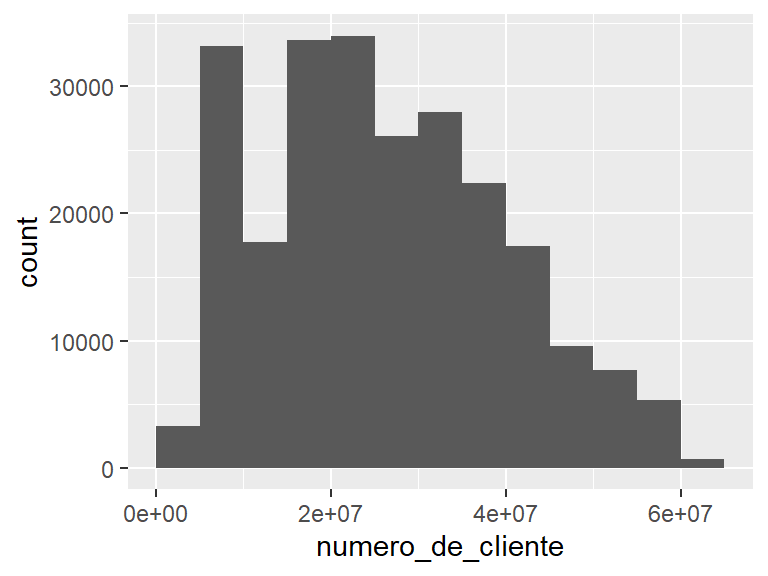

## foto_mes

- The variable only takes one (non-missing) value: "202011". The variable contains 0 % missing observations.

## active_quarter

- Note that this variable is treated as a factor variable below, as it only takes a few unique values.

| Feature | Result |
| --- | --- |
| Variable type | integer |
| Number of missing obs. | 0 (0 %) |
| Number of unique values | 2 |
| Mode | “1” |
| Reference category | 0 |

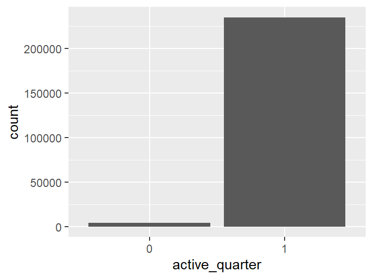

## cliente_vip

- Note that this variable is treated as a factor variable below, as it only takes a few unique values.

| Feature | Result |
| --- | --- |
| Variable type | integer |
| Number of missing obs. | 0 (0 %) |
| Number of unique values | 2 |
| Mode | “0” |
| Reference category | 0 |

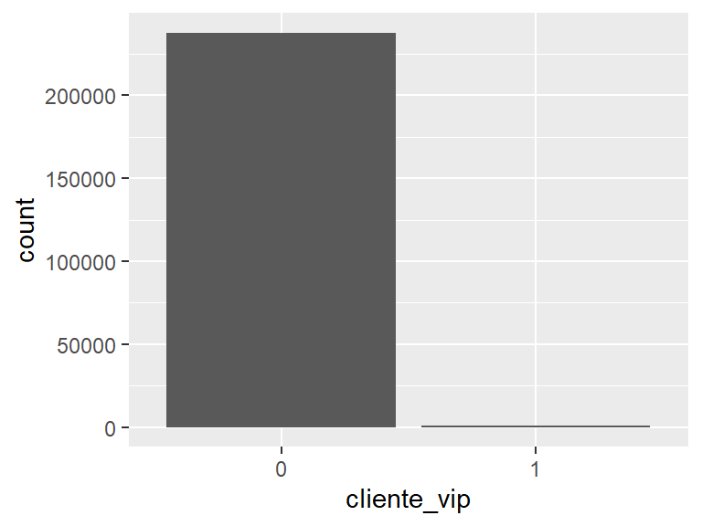

## internet

- Note that this variable is treated as a factor variable below, as it only takes a few unique values.

| Feature | Result |
| --- | --- |
| Variable type | integer |
| Number of missing obs. | 0 (0 %) |
| Number of unique values | 5 |
| Mode | “0” |
| Reference category | 0 |

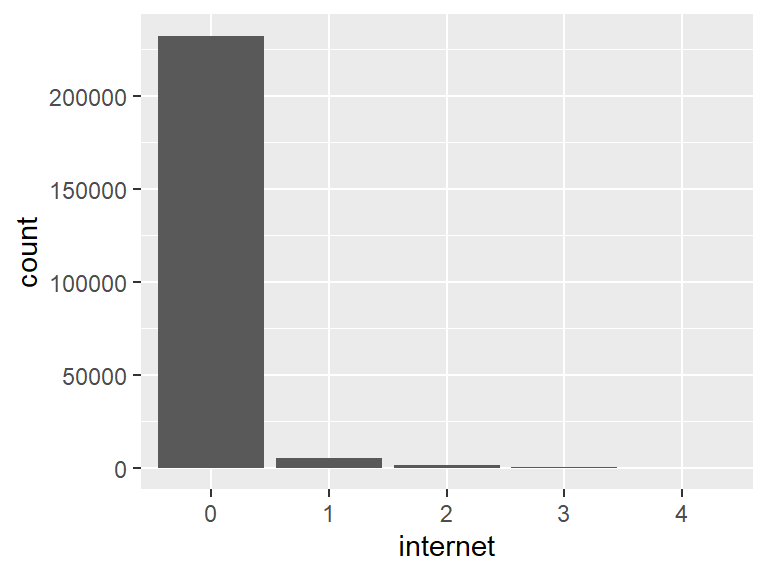

- Note that the following levels have at most five observations: "4".

## cliente_edad

| Feature | Result |
| --- | --- |
| Variable type | integer |
| Number of missing obs. | 0 (0 %) |
| Number of unique values | 81 |
| Median | 45 |
| 1st and 3rd quartiles | 37; 55 |
| Min. and max. | 18; 98 |

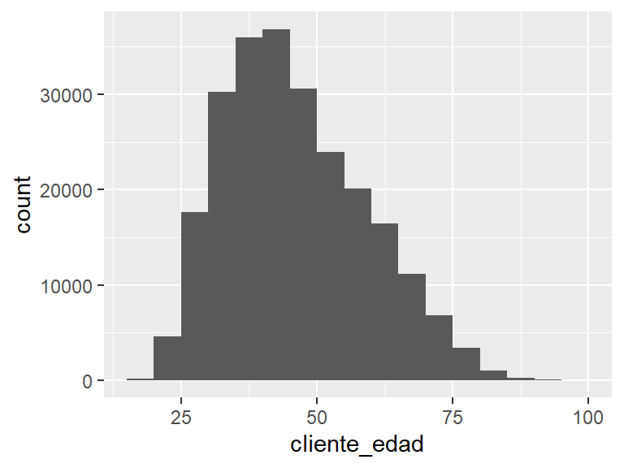

- Note that the following possible outlier values were detected: "18", "19", "20", "21", "97", "98".

## cliente_antiguedad

| Feature | Result |
| --- | --- |
| Variable type | integer |
| Number of missing obs. | 0 (0 %) |
| Number of unique values | 319 |
| Median | 124 |
| 1st and 3rd quartiles | 60; 185 |
| Min. and max. | 1; 371 |

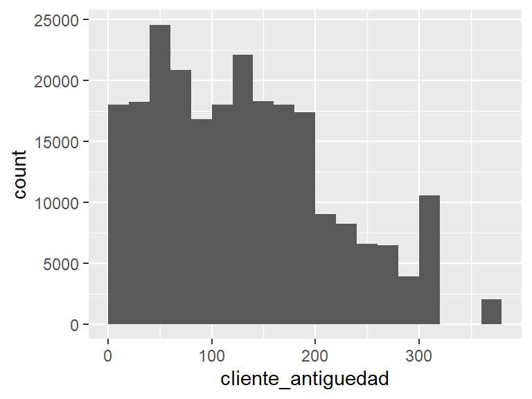

## mrentabilidad

| Feature | Result |
| --- | --- |
| Variable type | numeric |
| Number of missing obs. | 0 (0 %) |
| Number of unique values | 198672 |
| Median | 1018.98 |
| 1st and 3rd quartiles | 23.62; 2551.06 |
| Min. and max. | -639278.09; 634832.81 |

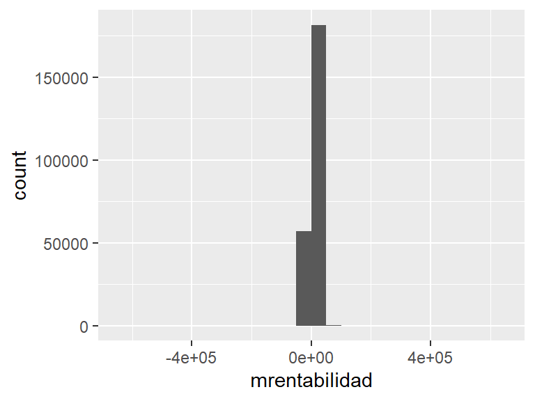

- Note that the following possible outlier values were detected: "-639278.09", "-564427.83", "-322637.11", "-254992.85", "-192810.41", "-161816.86", "-142079.05", "-109365.1", "-106268.78", "-99383.23" (29631 additional values omitted).

## mrentabilidad_annual

| Feature | Result |
| --- | --- |
| Variable type | numeric |
| Number of missing obs. | 0 (0 %) |
| Number of unique values | 233530 |
| Median | 14044.09 |
| 1st and 3rd quartiles | 3341.84; 31310.44 |
| Min. and max. | -3189342.83; 8446171.21 |

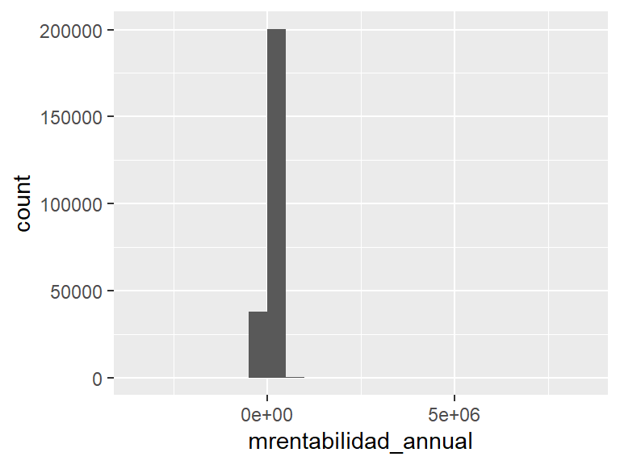

- Note that the following possible outlier values were detected: "-3189342.83", "-817834.58", "-771281.4", "-708413.72", "-573761.34", "-532284.58", "-530234.24", "-509351.88", "-503329.48", "-466326.06" (20710 additional values omitted).

## mcomisiones

| Feature | Result |
| --- | --- |
| Variable type | numeric |
| Number of missing obs. | 0 (0 %) |
| Number of unique values | 152462 |
| Median | 773.52 |
| 1st and 3rd quartiles | 242.28; 1682.37 |
| Min. and max. | -281818.04; 398536.69 |

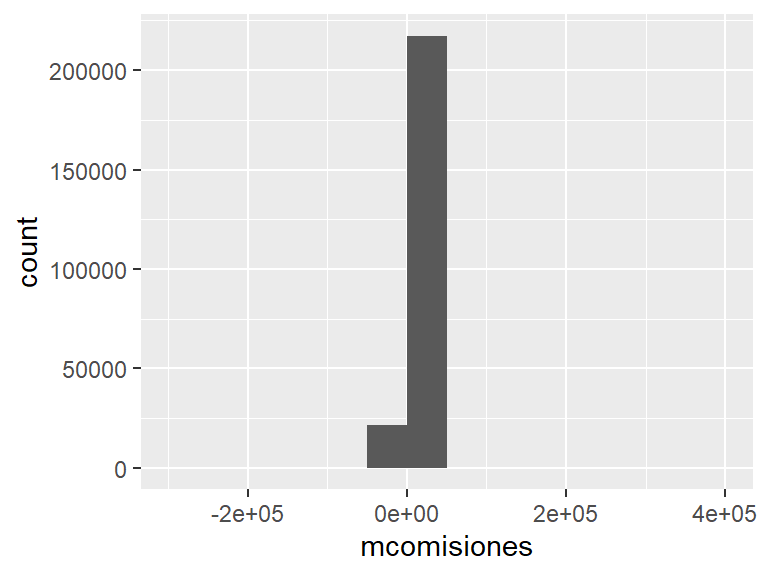

- Note that the following possible outlier values were detected: "-281818.04", "-137463.11", "-103016.79", "-49154.37", "-29682.38", "-25487.35", "-24659.36", "-22126.38", "-21734.14", "-20054.26" (6751 additional values omitted).

## mactivos_margen

| Feature | Result |
| --- | --- |
| Variable type | numeric |
| Number of missing obs. | 0 (0 %) |
| Number of unique values | 176348 |
| Median | -459.47 |
| 1st and 3rd quartiles | -1572.09; 0 |
| Min. and max. | -587532.54; 211352.13 |

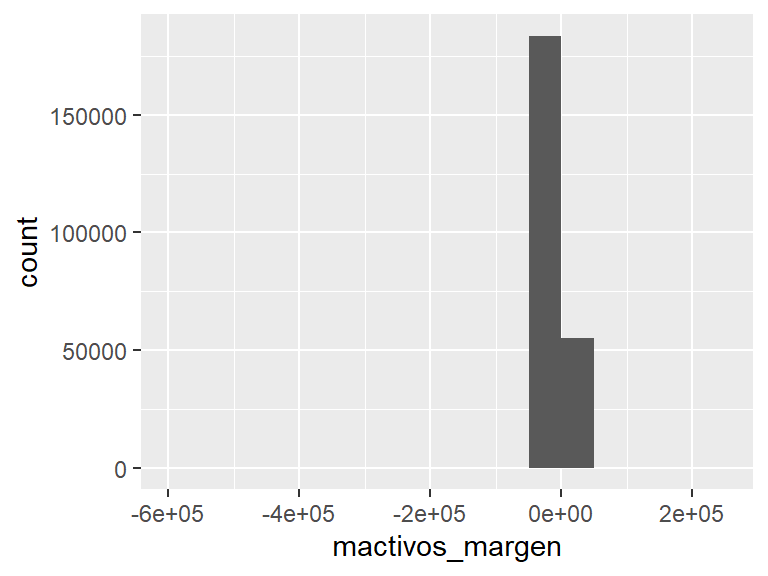

- Note that the following possible outlier values were detected: "-587532.54", "-286563.6", "-270948.12", "-227333.1", "-135234.32", "-125175.52", "-120275.24", "-114541.23", "-113289.92", "-108450.2" (28647 additional values omitted).

## mpasivos_margen

| Feature | Result |
| --- | --- |
| Variable type | numeric |
| Number of missing obs. | 0 (0 %) |
| Number of unique values | 157968 |
| Median | 655.9 |
| 1st and 3rd quartiles | 234.06; 1555.71 |
| Min. and max. | -38485.88; 506270.9 |

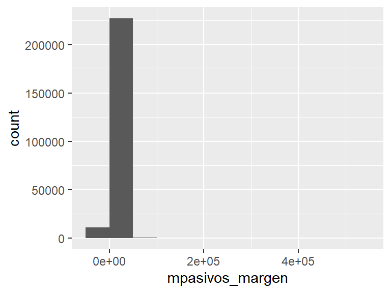

- Note that the following possible outlier values were detected: "-38485.88", "-37958.03", "-37798.67", "-37651.11", "-37649.38", "-37527.54", "-37521.23", "-37462.94", "-37196.76", "-37130.33" (12581 additional values omitted).

## cproductos

| Feature | Result |
| --- | --- |
| Variable type | integer |
| Number of missing obs. | 0 (0 %) |
| Number of unique values | 16 |
| Median | 7 |
| 1st and 3rd quartiles | 7; 8 |
| Min. and max. | 3; 18 |

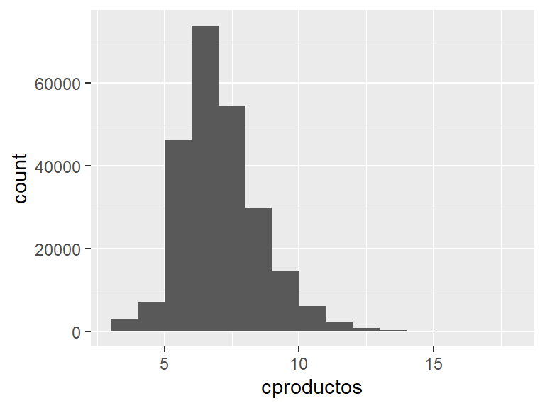

- Note that the following possible outlier values were detected: "3", "4", "5", "6", "14", "15", "16", "17", "18".

## tpaquete1

- Note that this variable is treated as a factor variable below, as it only takes a few unique values.

| Feature | Result |
| --- | --- |
| Variable type | integer |
| Number of missing obs. | 0 (0 %) |
| Number of unique values | 2 |
| Mode | “1” |
| Reference category | 1 |

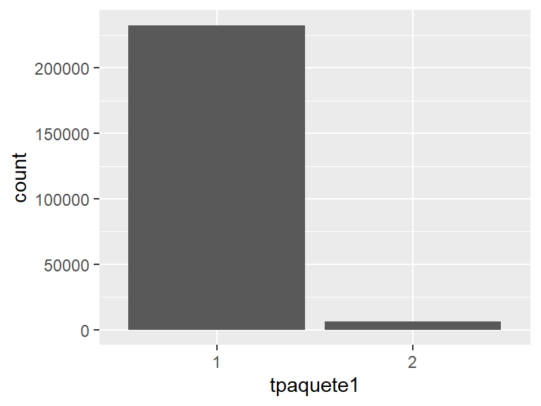

## tpaquete3

- Note that this variable is treated as a factor variable below, as it only takes a few unique values.

| Feature | Result |
| --- | --- |
| Variable type | integer |
| Number of missing obs. | 0 (0 %) |
| Number of unique values | 2 |
| Mode | “0” |
| Reference category | 0 |

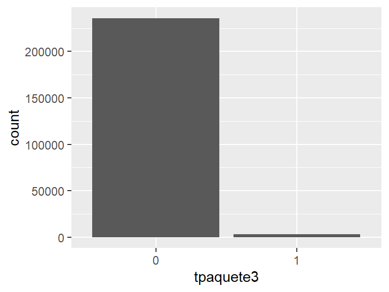

## tpaquete4

- Note that this variable is treated as a factor variable below, as it only takes a few unique values.

| Feature | Result |
| --- | --- |
| Variable type | integer |
| Number of missing obs. | 0 (0 %) |
| Number of unique values | 2 |
| Mode | “0” |
| Reference category | 0 |

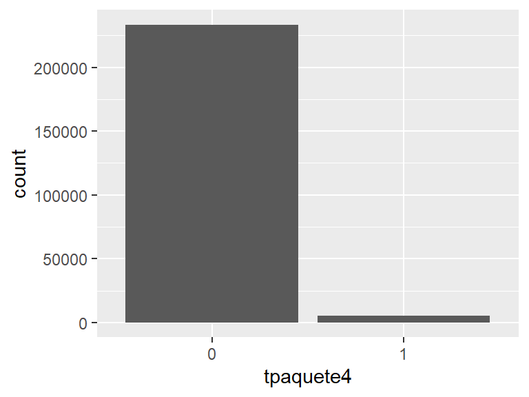

## tcuentas

- Note that this variable is treated as a factor variable below, as it only takes a few unique values.

| Feature | Result |
| --- | --- |
| Variable type | integer |
| Number of missing obs. | 0 (0 %) |
| Number of unique values | 2 |
| Mode | “1” |
| Reference category | 1 |

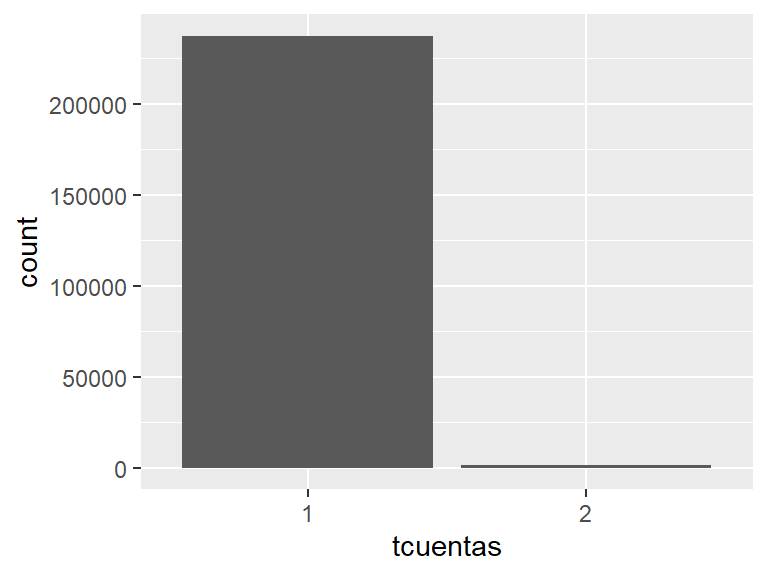

## ccuenta_corriente

- Note that this variable is treated as a factor variable below, as it only takes a few unique values.

| Feature | Result |
| --- | --- |
| Variable type | integer |
| Number of missing obs. | 0 (0 %) |
| Number of unique values | 4 |
| Mode | “1” |
| Reference category | 1 |

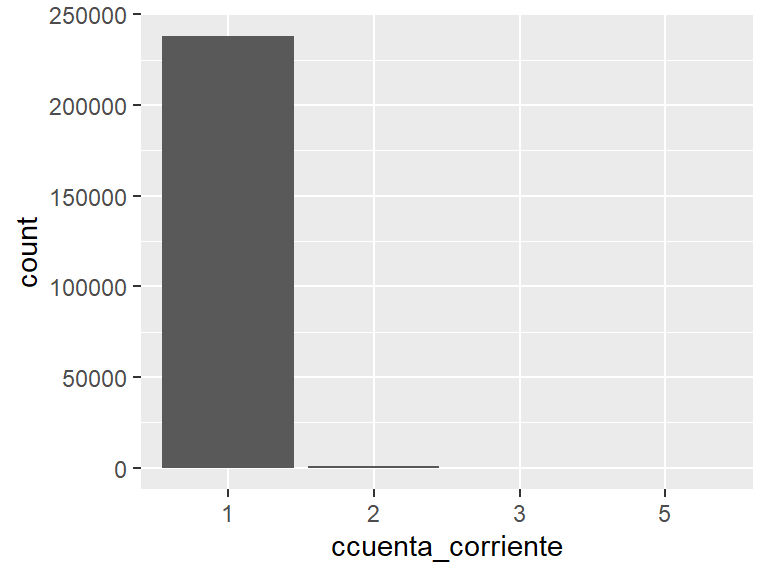

- Note that the following levels have at most five observations: "5".

## mcuenta_corriente_adicional

| Feature | Result |
| --- | --- |
| Variable type | numeric |
| Number of missing obs. | 0 (0 %) |
| Number of unique values | 137 |
| Median | 0 |
| 1st and 3rd quartiles | 0; 0 |
| Min. and max. | -17437.23; 18637853.45 |

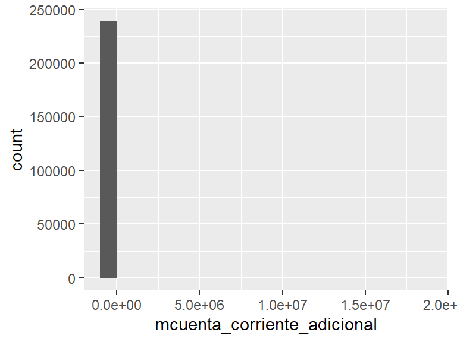

- Note that the following possible outlier values were detected: "-17437.23", "-12044.52", "-7678.12", "-3619.48", "-1468.81", "-476.61", "-427.15", "-122.47", "-72.61", "-65.32" (126 additional values omitted).

## mcuenta_corriente

| Feature | Result |
| --- | --- |
| Variable type | numeric |
| Number of missing obs. | 0 (0 %) |
| Number of unique values | 100463 |
| Median | 0 |
| 1st and 3rd quartiles | -713.69; 0 |
| Min. and max. | -29555346.34; 30517421.37 |

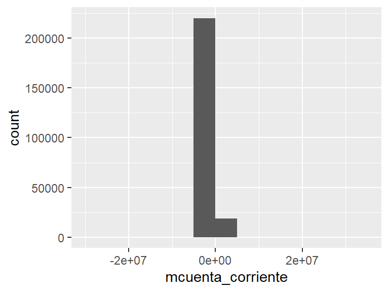

- Note that the following possible outlier values were detected: "-29555346.34", "-3306477.92", "-2713005.61", "-2060485.11", "-1690102.15", "-1689467.46", "-1469843.08", "-1411843.05", "-1389578.86", "-1277894.8" (22089 additional values omitted).

## ccaja_ahorro

| Feature | Result |
| --- | --- |
| Variable type | integer |
| Number of missing obs. | 0 (0 %) |
| Number of unique values | 10 |
| Median | 2 |
| 1st and 3rd quartiles | 2; 2 |
| Min. and max. | 2; 12 |

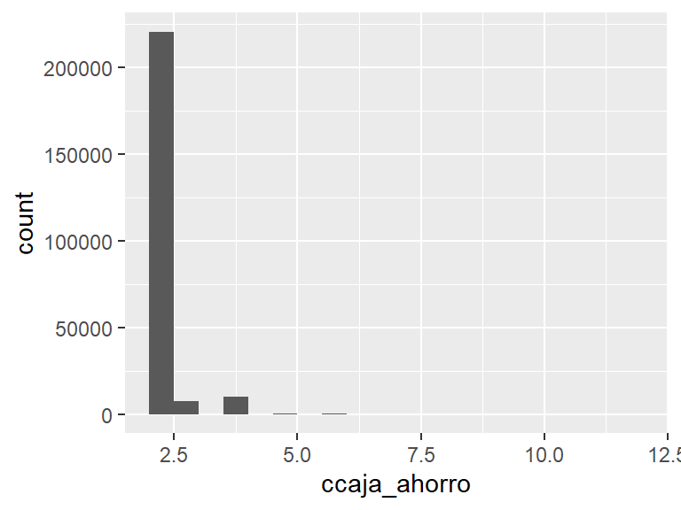

- Note that the following possible outlier values were detected: "3", "4", "5", "6", "7", "8", "9", "10", "12".

## mcaja_ahorro

| Feature | Result |
| --- | --- |
| Variable type | numeric |
| Number of missing obs. | 0 (0 %) |
| Number of unique values | 217185 |
| Median | 19356.86 |
| 1st and 3rd quartiles | 4768.7; 57021.71 |
| Min. and max. | -1131.97; 26956765.2 |

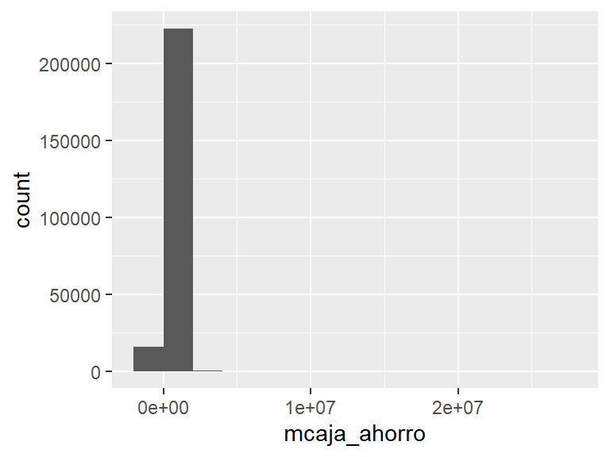

- Note that the following possible outlier values were detected: "446160.88", "446368.79", "446476.92", "446550.42", "446557.49", "446569.05", "446608.18", "446623.83", "446645.3", "446658.35" (5846 additional values omitted).

## mcaja_ahorro_adicional

| Feature | Result |
| --- | --- |
| Variable type | numeric |
| Number of missing obs. | 0 (0 %) |
| Number of unique values | 5046 |
| Median | 0 |
| 1st and 3rd quartiles | 0; 0 |
| Min. and max. | -4581.59; 2373009.11 |

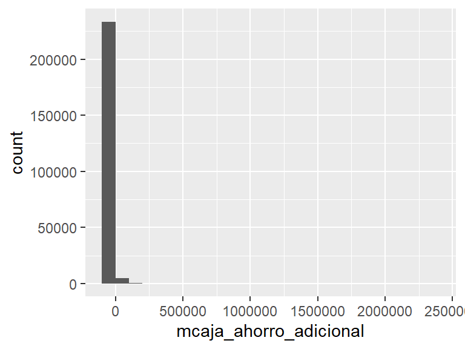

- Note that the following possible outlier values were detected: "-4581.59", "-2801.14", "-784.99", "-764.3", "-376.47", "-101.39", "-62.6", "-54.87", "-13.13", "0.01" (5035 additional values omitted).

## mcaja_ahorro_dolares

| Feature | Result |
| --- | --- |
| Variable type | numeric |
| Number of missing obs. | 0 (0 %) |
| Number of unique values | 53523 |
| Median | 37.1 |
| 1st and 3rd quartiles | 0; 19023.42 |
| Min. and max. | -13480.95; 430807320.52 |

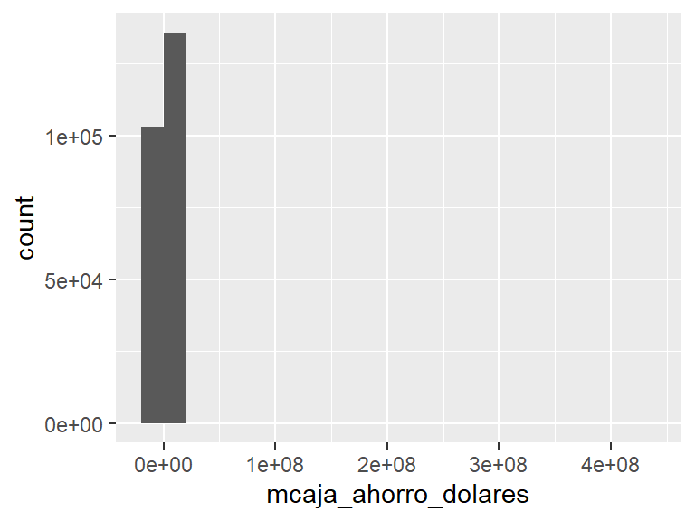

- Note that the following possible outlier values were detected: "-13480.95", "-9511.71", "-6621.1", "-6612.54", "-5897.26", "-5612.86", "-3804.68", "-2853.51", "-2852.56", "-2535.82" (6710 additional values omitted).

## mdescubierto_preacordado

- Note that this variable is treated as a factor variable below, as it only takes a few unique values.

| Feature | Result |
| --- | --- |
| Variable type | numeric |
| Number of missing obs. | 0 (0 %) |
| Number of unique values | 2 |
| Mode | “1.17” |
| Reference category | 0 |

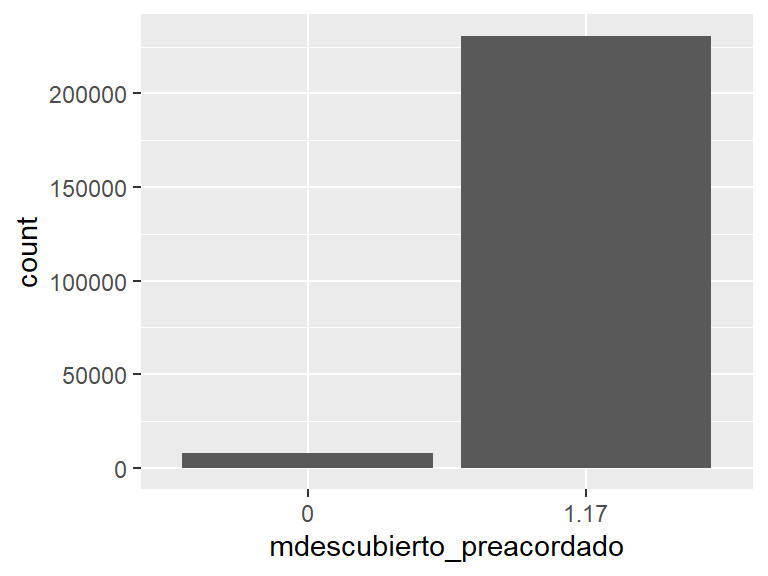

## mcuentas_saldo

| Feature | Result |
| --- | --- |
| Variable type | numeric |
| Number of missing obs. | 0 (0 %) |
| Number of unique values | 232462 |
| Median | 30039.52 |
| 1st and 3rd quartiles | 869.9; 118670.09 |
| Min. and max. | -29792615.86; 431951288.46 |

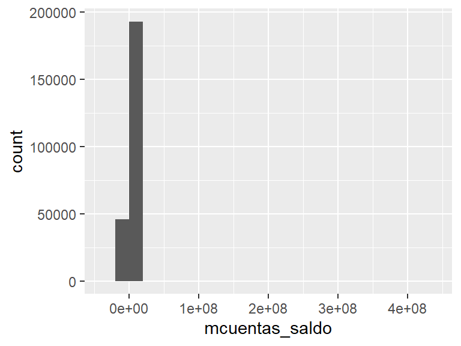

- Note that the following possible outlier values were detected: "-29792615.86", "-3264196.53", "-2712995.09", "-2060485.11", "-1729039.57", "-1690054.49", "-1505922.21", "-1411840.2", "-1389578.86", "-1277894.8" (13712 additional values omitted).

## ctarjeta_debito

| Feature | Result |
| --- | --- |
| Variable type | integer |
| Number of missing obs. | 0 (0 %) |
| Number of unique values | 16 |
| Median | 1 |
| 1st and 3rd quartiles | 1; 2 |
| Min. and max. | 0; 114 |

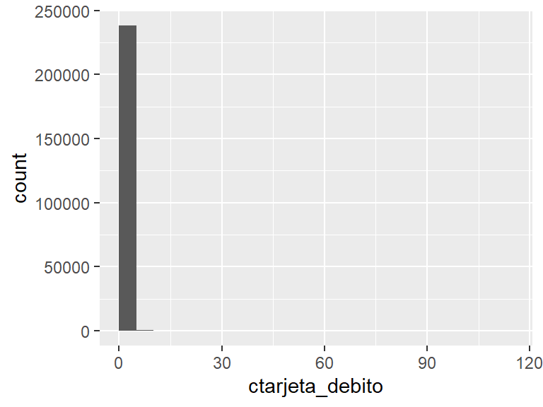

- Note that the following possible outlier values were detected: "0", "52", "114".

## ctarjeta_debito_transacciones

| Feature | Result |
| --- | --- |
| Variable type | integer |
| Number of missing obs. | 0 (0 %) |
| Number of unique values | 119 |
| Median | 3 |
| 1st and 3rd quartiles | 0; 10 |
| Min. and max. | 0; 153 |

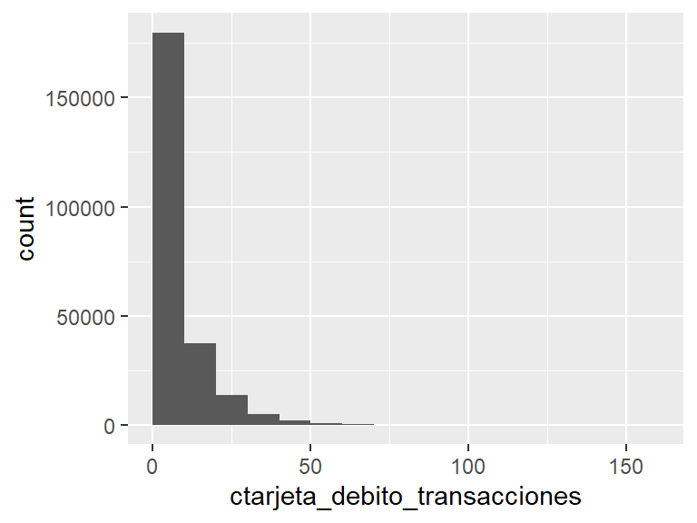

- Note that the following possible outlier values were detected: "78", "79", "80", "81", "82", "83", "84", "85", "86", "87" (31 additional values omitted).

## mautoservicio

| Feature | Result |
| --- | --- |
| Variable type | numeric |
| Number of missing obs. | 0 (0 %) |
| Number of unique values | 138253 |
| Median | 5409.82 |
| 1st and 3rd quartiles | 0; 19619.28 |
| Min. and max. | 0; 717098.07 |

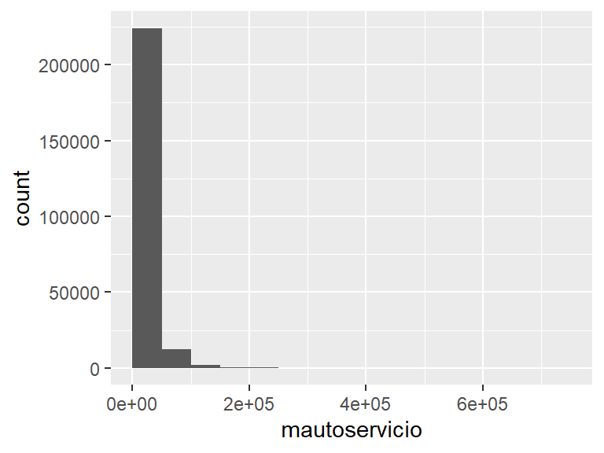

- Note that the following possible outlier values were detected: "165771.09", "165790.55", "165905.56", "165921.68", "165963.03", "165977.55", "166023", "166180.57", "166454.98", "166510.97" (562 additional values omitted).

## ctarjeta_visa

- Note that this variable is treated as a factor variable below, as it only takes a few unique values.

| Feature | Result |
| --- | --- |
| Variable type | integer |
| Number of missing obs. | 0 (0 %) |
| Number of unique values | 4 |
| Mode | “1” |
| Reference category | 0 |

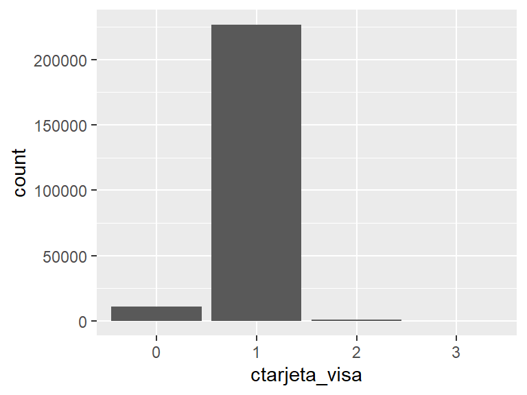

## ctarjeta_visa_transacciones

| Feature | Result |
| --- | --- |
| Variable type | integer |
| Number of missing obs. | 0 (0 %) |
| Number of unique values | 179 |
| Median | 8 |
| 1st and 3rd quartiles | 3; 16 |
| Min. and max. | 0; 395 |

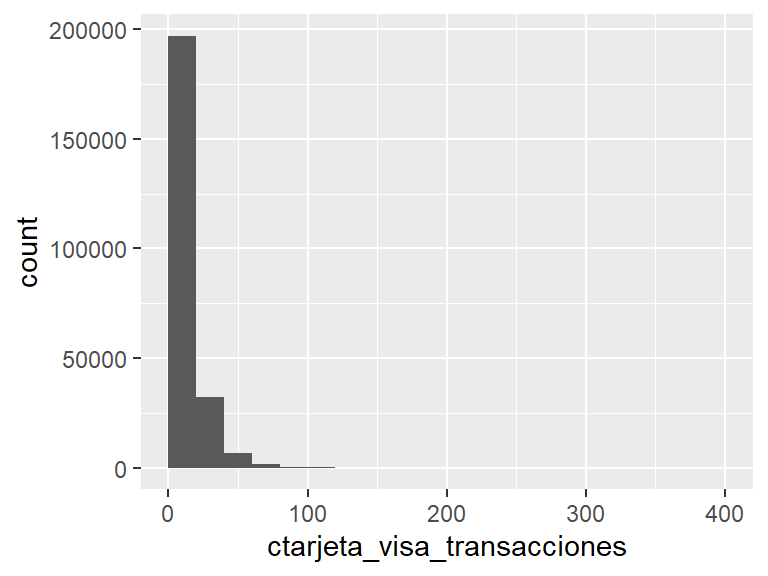

- Note that the following possible outlier values were detected: "64", "65", "66", "67", "68", "69", "70", "71", "72", "73" (105 additional values omitted).

## mtarjeta_visa_consumo

| Feature | Result |
| --- | --- |
| Variable type | numeric |
| Number of missing obs. | 0 (0 %) |
| Number of unique values | 193891 |
| Median | 15612.38 |
| 1st and 3rd quartiles | 4064.66; 35717.82 |
| Min. and max. | 0; 2510622.01 |

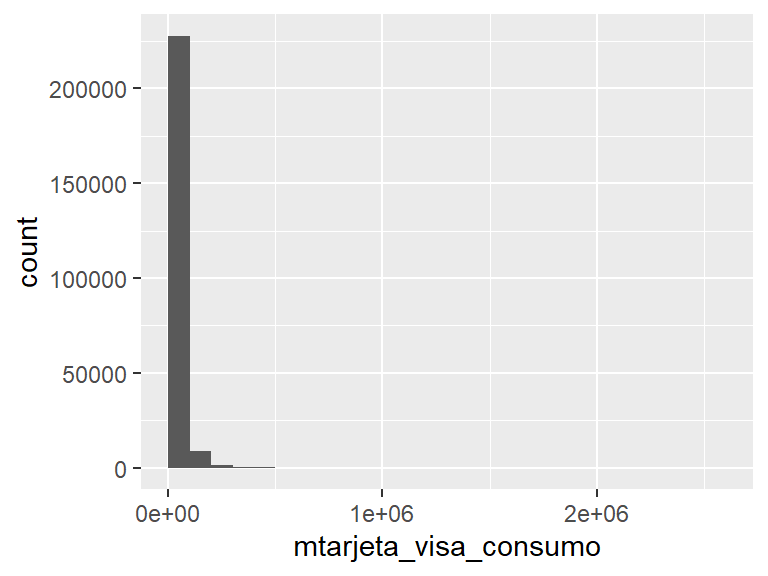

- Note that the following possible outlier values were detected: "178384.57", "178400.86", "178406.06", "178428.98", "178430.96", "178452.05", "178462.21", "178469.2", "178470.05", "178503.81" (3150 additional values omitted).

## ctarjeta_master

- Note that this variable is treated as a factor variable below, as it only takes a few unique values.

| Feature | Result |
| --- | --- |
| Variable type | integer |
| Number of missing obs. | 0 (0 %) |
| Number of unique values | 3 |
| Mode | “1” |
| Reference category | 0 |

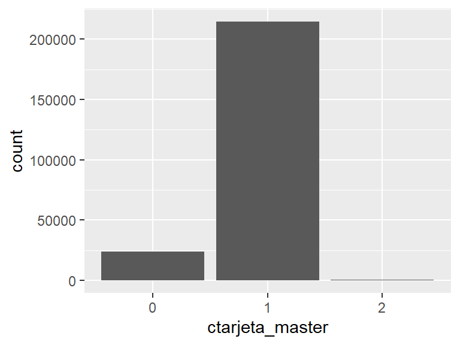

## ctarjeta_master_transacciones

| Feature | Result |
| --- | --- |
| Variable type | integer |
| Number of missing obs. | 0 (0 %) |
| Number of unique values | 113 |
| Median | 0 |
| 1st and 3rd quartiles | 0; 2 |
| Min. and max. | 0; 458 |

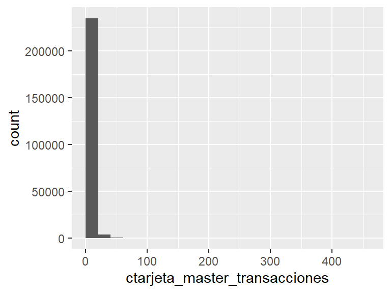

- Note that the following possible outlier values were detected: "63", "64", "65", "66", "67", "68", "69", "70", "71", "72" (40 additional values omitted).

## mtarjeta_master_consumo

| Feature | Result |
| --- | --- |
| Variable type | numeric |
| Number of missing obs. | 0 (0 %) |
| Number of unique values | 74439 |
| Median | 0 |
| 1st and 3rd quartiles | 0; 3441.53 |
| Min. and max. | 0; 3274959.72 |

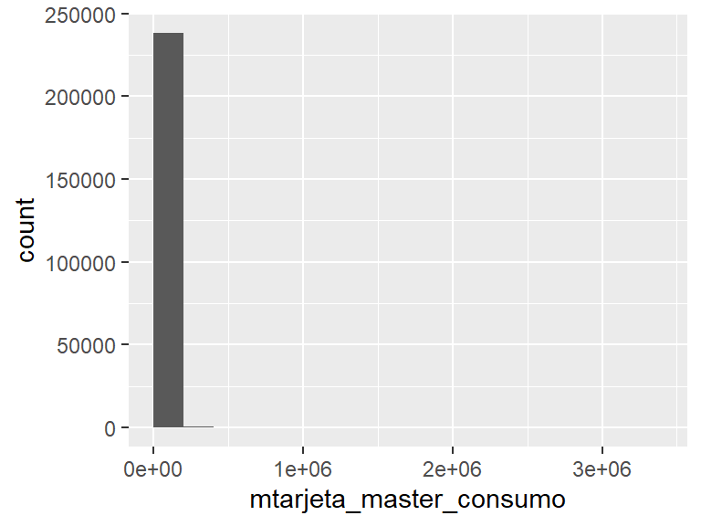

- Note that the following possible outlier values were detected: "107158.52", "107201.98", "107240.76", "107248.98", "107271.63", "107317.75", "107456.29", "107456.6", "107477.61", "107499.17" (1805 additional values omitted).

## cprestamos_personales

| Feature | Result |
| --- | --- |
| Variable type | integer |
| Number of missing obs. | 0 (0 %) |
| Number of unique values | 126 |
| Median | 0 |
| 1st and 3rd quartiles | 0; 0 |
| Min. and max. | 0; 421 |

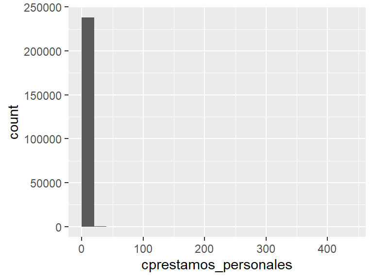

- Note that the following possible outlier values were detected: "1", "2", "3", "4", "5", "6", "7", "8", "9", "10" (115 additional values omitted).

## mprestamos_personales

| Feature | Result |
| --- | --- |
| Variable type | numeric |
| Number of missing obs. | 0 (0 %) |
| Number of unique values | 44790 |
| Median | 0 |
| 1st and 3rd quartiles | 0; 0 |
| Min. and max. | 0; 3680198.8 |

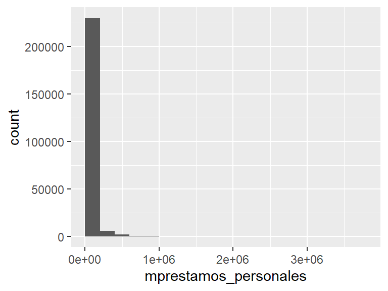

- Note that the following possible outlier values were detected: "32.72", "198.27", "209.38", "221.65", "240.98", "249.87", "262.91", "278.12", "281.29", "298.85" (44779 additional values omitted).

## cprestamos_prendarios

| Feature | Result |
| --- | --- |
| Variable type | integer |
| Number of missing obs. | 0 (0 %) |
| Number of unique values | 14 |
| Median | 0 |
| 1st and 3rd quartiles | 0; 0 |
| Min. and max. | 0; 18 |

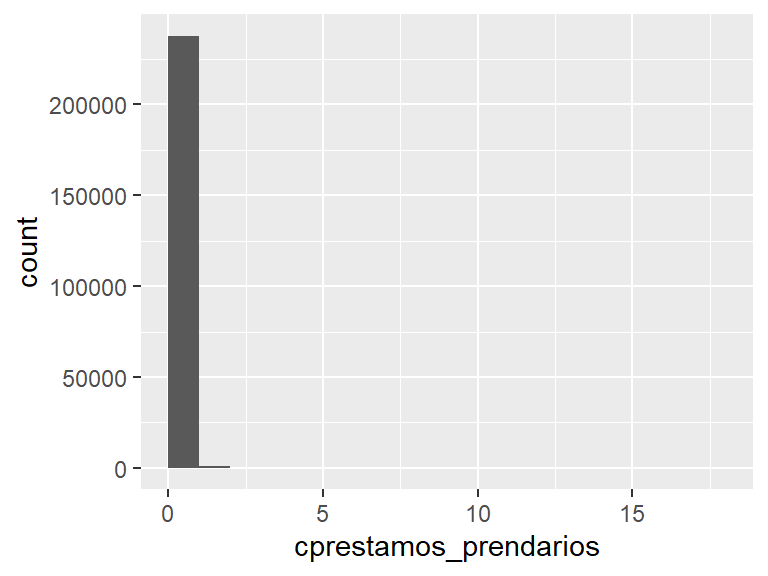

- Note that the following possible outlier values were detected: "1", "2", "3", "4", "5", "6", "7", "8", "9", "10" (3 additional values omitted).

## mprestamos_prendarios

| Feature | Result |
| --- | --- |
| Variable type | numeric |
| Number of missing obs. | 0 (0 %) |
| Number of unique values | 2340 |
| Median | 0 |
| 1st and 3rd quartiles | 0; 0 |
| Min. and max. | 0; 22003279.58 |

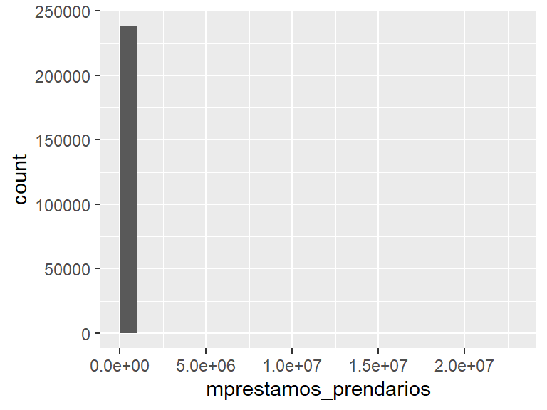

- Note that the following possible outlier values were detected: "81.27", "94.48", "105.66", "150.45", "161.88", "195.54", "307.61", "317.71", "324.39", "350.97" (2329 additional values omitted).

## cprestamos_hipotecarios

| Feature | Result |
| --- | --- |
| Variable type | integer |
| Number of missing obs. | 0 (0 %) |
| Number of unique values | 14 |
| Median | 0 |
| 1st and 3rd quartiles | 0; 0 |
| Min. and max. | 0; 18 |

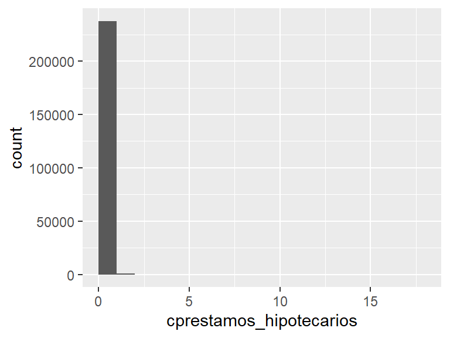

- Note that the following possible outlier values were detected: "1", "2", "3", "4", "5", "6", "7", "8", "9", "10" (3 additional values omitted).

## mprestamos_hipotecarios

| Feature | Result |
| --- | --- |
| Variable type | numeric |
| Number of missing obs. | 0 (0 %) |
| Number of unique values | 2883 |
| Median | 0 |
| 1st and 3rd quartiles | 0; 0 |
| Min. and max. | 0; 29328134.54 |

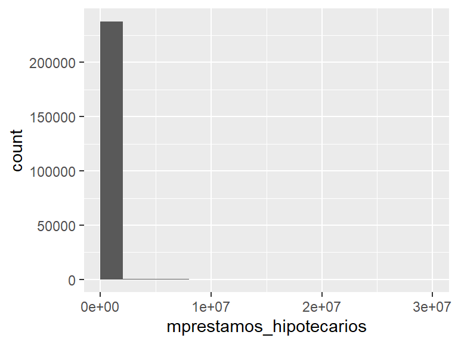

- Note that the following possible outlier values were detected: "493.74", "642.7", "687.96", "707.85", "708.06", "872.77", "929.4", "954.32", "1084.47", "1094.39" (2872 additional values omitted).

## cplazo_fijo

| Feature | Result |
| --- | --- |
| Variable type | integer |
| Number of missing obs. | 0 (0 %) |
| Number of unique values | 50 |
| Median | 0 |
| 1st and 3rd quartiles | 0; 0 |
| Min. and max. | 0; 79 |

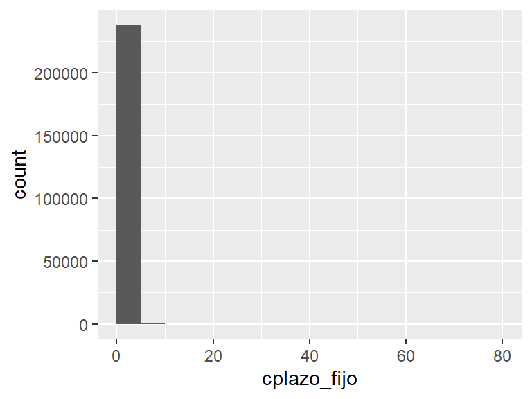

- Note that the following possible outlier values were detected: "1", "2", "3", "4", "5", "6", "7", "8", "9", "10" (39 additional values omitted).

## mplazo_fijo_dolares

| Feature | Result |
| --- | --- |
| Variable type | numeric |
| Number of missing obs. | 0 (0 %) |
| Number of unique values | 7709 |
| Median | 0 |
| 1st and 3rd quartiles | 0; 0 |
| Min. and max. | 0; 70777352.27 |

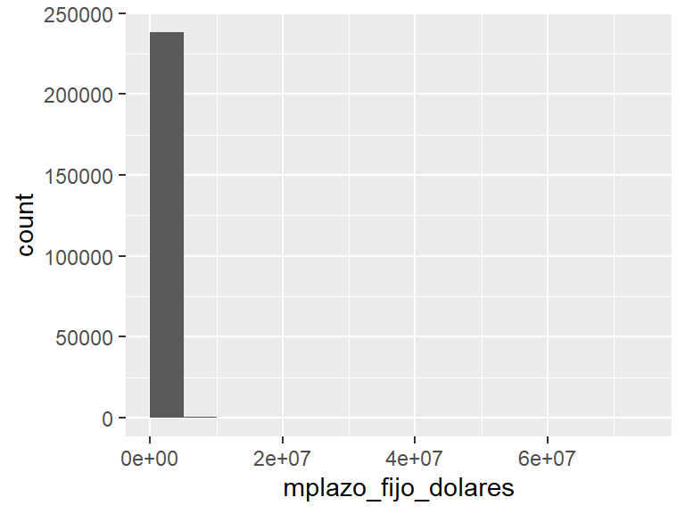

- Note that the following possible outlier values were detected: "585", "607.56", "643.5", "675.52", "702", "702.02", "712.38", "715.82", "720", "733.59" (7698 additional values omitted).

## mplazo_fijo_pesos

| Feature | Result |
| --- | --- |
| Variable type | numeric |
| Number of missing obs. | 0 (0 %) |
| Number of unique values | 671 |
| Median | 0 |
| 1st and 3rd quartiles | 0; 0 |
| Min. and max. | 0; 32843657.99 |

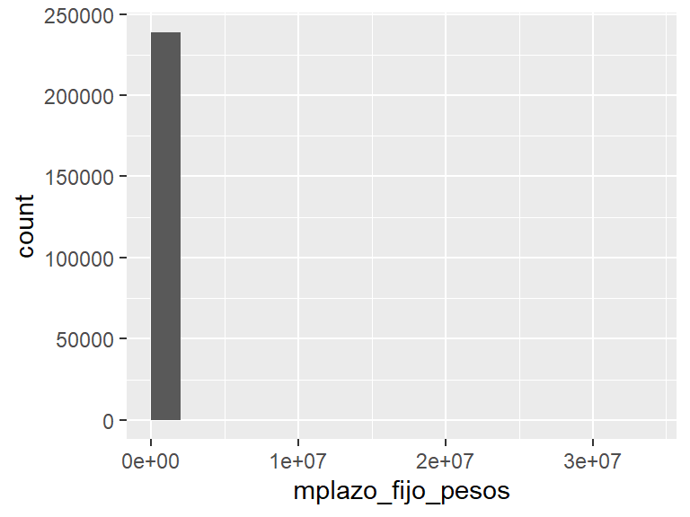

- Note that the following possible outlier values were detected: "47558.56", "47560.47", "47562.37", "47564.27", "47568.08", "47569.98", "47580.44", "47581.39", "47589", "47592.81" (660 additional values omitted).

## cinversion1

| Feature | Result |
| --- | --- |
| Variable type | integer |
| Number of missing obs. | 0 (0 %) |
| Number of unique values | 14 |
| Median | 0 |
| 1st and 3rd quartiles | 0; 0 |
| Min. and max. | 0; 13 |

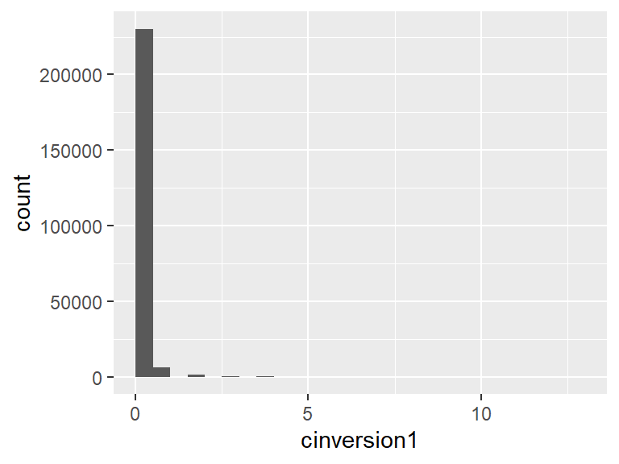

- Note that the following possible outlier values were detected: "1", "2", "3", "4", "5", "6", "7", "8", "9", "10" (3 additional values omitted).

## minversion1_pesos

| Feature | Result |
| --- | --- |
| Variable type | numeric |
| Number of missing obs. | 0 (0 %) |
| Number of unique values | 8107 |
| Median | 0 |
| 1st and 3rd quartiles | 0; 0 |
| Min. and max. | 0; 79475988.32 |

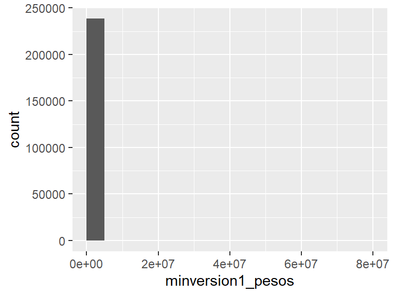

- Note that the following possible outlier values were detected: "0.08", "1.33", "1.54", "1.56", "1.76", "2.41", "2.43", "2.44", "2.58", "2.78" (8096 additional values omitted).

## minversion1_dolares

| Feature | Result |
| --- | --- |
| Variable type | numeric |
| Number of missing obs. | 0 (0 %) |
| Number of unique values | 985 |
| Median | 0 |
| 1st and 3rd quartiles | 0; 0 |
| Min. and max. | 0; 52276252.13 |

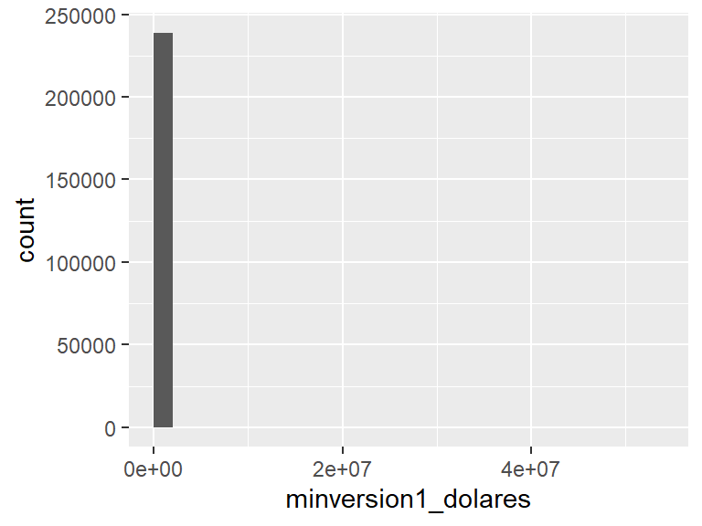

- Note that the following possible outlier values were detected: "100.81", "104.63", "110.33", "113.18", "132.21", "170.25", "198.79", "218.76", "232.08", "233.98" (974 additional values omitted).

## cinversion2

| Feature | Result |
| --- | --- |
| Variable type | integer |
| Number of missing obs. | 0 (0 %) |
| Number of unique values | 49 |
| Median | 0 |
| 1st and 3rd quartiles | 0; 0 |
| Min. and max. | 0; 56 |

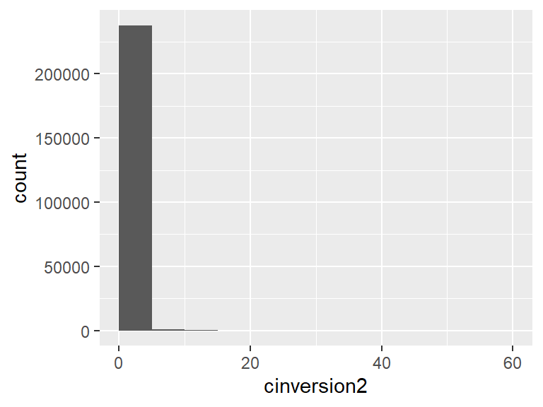

- Note that the following possible outlier values were detected: "1", "2", "3", "4", "5", "6", "7", "8", "9", "10" (38 additional values omitted).

## minversion2

| Feature | Result |
| --- | --- |
| Variable type | numeric |
| Number of missing obs. | 0 (0 %) |
| Number of unique values | 7731 |
| Median | 0 |
| 1st and 3rd quartiles | 0; 0 |
| Min. and max. | 0; 724241918.95 |

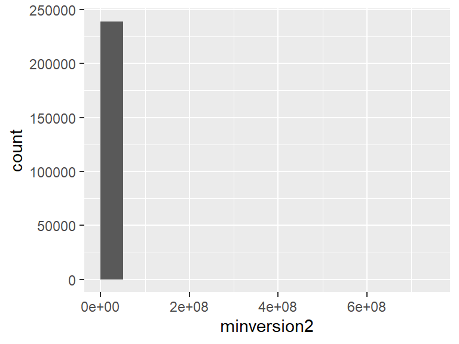

- Note that the following possible outlier values were detected: "0.01", "0.02", "0.03", "0.05", "0.07", "0.08", "0.09", "0.1", "0.12", "0.14" (7720 additional values omitted).

## cseguro_vida

- Note that this variable is treated as a factor variable below, as it only takes a few unique values.

| Feature | Result |
| --- | --- |
| Variable type | integer |
| Number of missing obs. | 0 (0 %) |
| Number of unique values | 5 |
| Mode | “0” |
| Reference category | 0 |

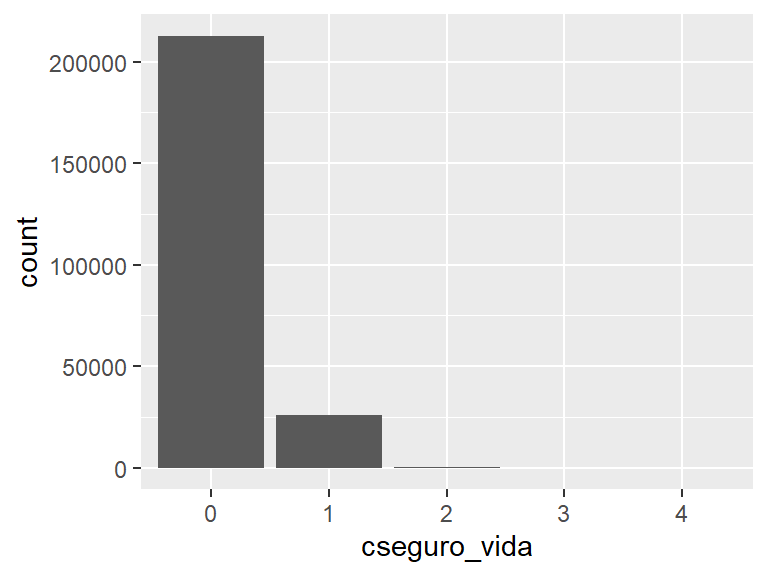

- Note that the following levels have at most five observations: "3", "4".

## cseguro_auto

| Feature | Result |
| --- | --- |
| Variable type | integer |
| Number of missing obs. | 0 (0 %) |
| Number of unique values | 8 |
| Median | 0 |
| 1st and 3rd quartiles | 0; 0 |
| Min. and max. | 0; 10 |

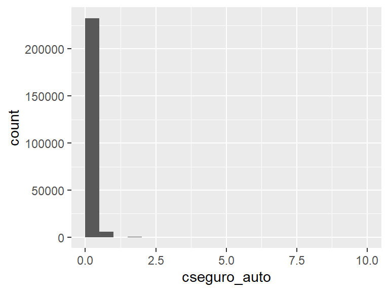

- Note that the following possible outlier values were detected: "1", "2", "3", "4", "5", "6", "10".

## cseguro_vivienda

| Feature | Result |
| --- | --- |
| Variable type | integer |
| Number of missing obs. | 0 (0 %) |
| Number of unique values | 7 |
| Median | 0 |
| 1st and 3rd quartiles | 0; 0 |
| Min. and max. | 0; 7 |

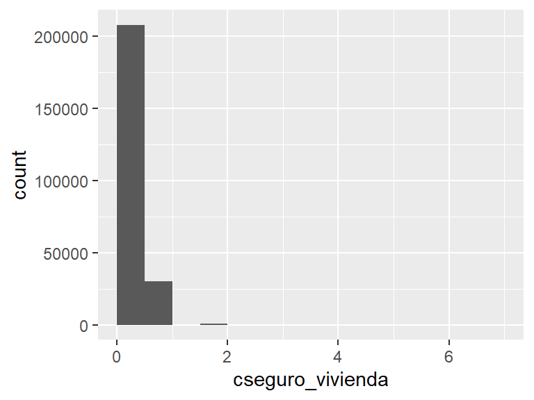

- Note that the following possible outlier values were detected: "1", "2", "3", "4", "5", "7".

## cseguro_accidentes_personales

- Note that this variable is treated as a factor variable below, as it only takes a few unique values.

| Feature | Result |
| --- | --- |
| Variable type | integer |
| Number of missing obs. | 0 (0 %) |
| Number of unique values | 4 |
| Mode | “0” |
| Reference category | 0 |

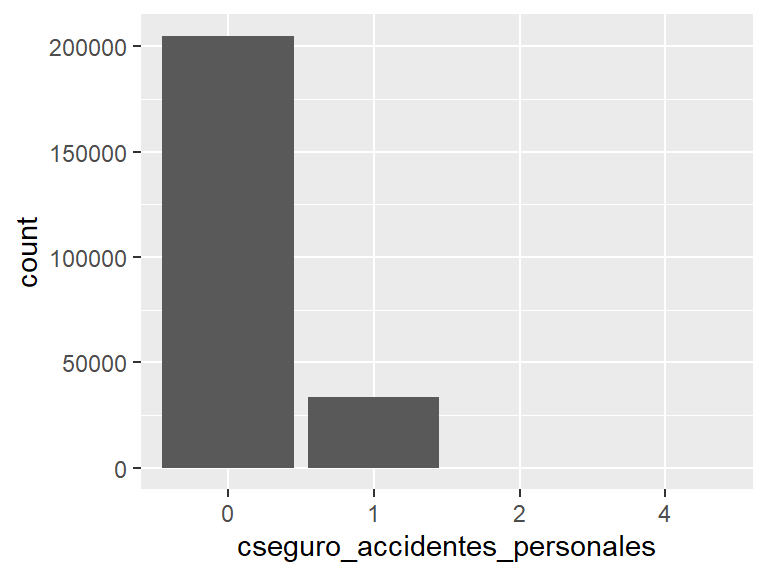

- Note that the following levels have at most five observations: "4".

## ccaja_seguridad

| Feature | Result |
| --- | --- |
| Variable type | integer |
| Number of missing obs. | 0 (0 %) |
| Number of unique values | 7 |
| Median | 0 |
| 1st and 3rd quartiles | 0; 0 |
| Min. and max. | 0; 6 |

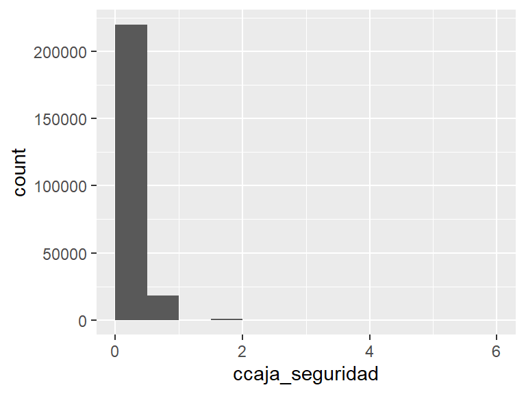

- Note that the following possible outlier values were detected: "1", "2", "3", "4", "5", "6".

## cpayroll_trx

| Feature | Result |
| --- | --- |
| Variable type | integer |
| Number of missing obs. | 0 (0 %) |
| Number of unique values | 38 |
| Median | 1 |
| 1st and 3rd quartiles | 0; 1 |
| Min. and max. | 0; 108 |

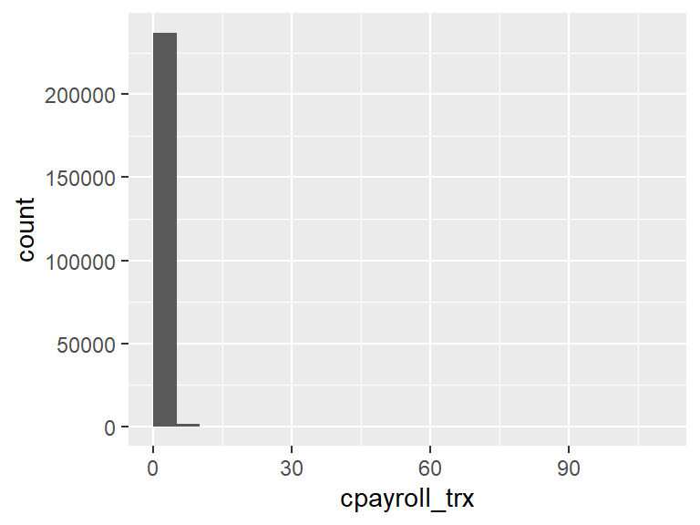

- Note that the following possible outlier values were detected: "3", "4", "5", "6", "7", "8", "9", "10", "11", "12" (25 additional values omitted).

## mpayroll

| Feature | Result |
| --- | --- |
| Variable type | numeric |
| Number of missing obs. | 0 (0 %) |
| Number of unique values | 104435 |
| Median | 7153.96 |
| 1st and 3rd quartiles | 0; 84259.6 |
| Min. and max. | 0; 77015656.99 |

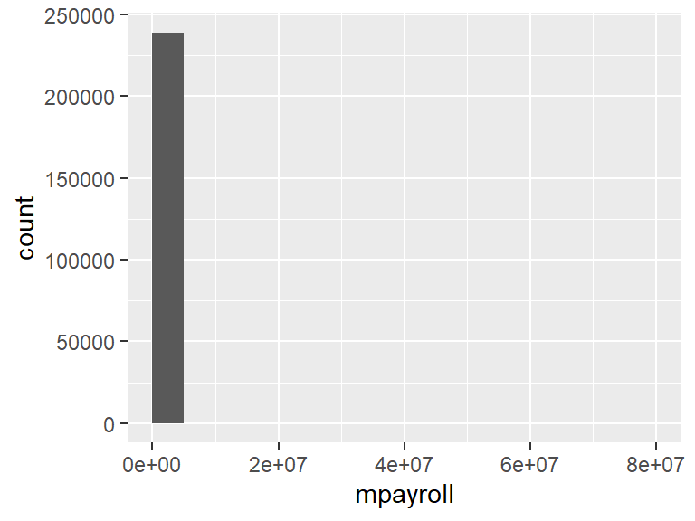

- Note that the following possible outlier values were detected: "1630371.6", "1636810.11", "1638000", "1644579.99", "1659485.68", "1664077.82", "1676523.52", "1677051.09", "1702550.07", "1731600" (218 additional values omitted).

## mpayroll2

| Feature | Result |
| --- | --- |
| Variable type | numeric |
| Number of missing obs. | 0 (0 %) |
| Number of unique values | 188 |
| Median | 0 |
| 1st and 3rd quartiles | 0; 0 |
| Min. and max. | 0; 360094.41 |

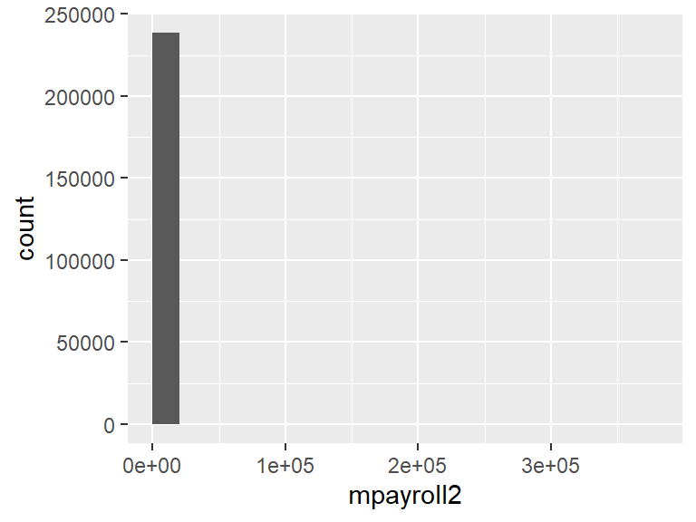

- Note that the following possible outlier values were detected: "1527.04", "4095", "4212", "4680", "4755.38", "4837.95", "5265", "5850", "6199.09", "6435" (177 additional values omitted).

## cpayroll2_trx

| Feature | Result |
| --- | --- |
| Variable type | integer |
| Number of missing obs. | 0 (0 %) |
| Number of unique values | 6 |
| Median | 0 |
| 1st and 3rd quartiles | 0; 0 |
| Min. and max. | 0; 5 |

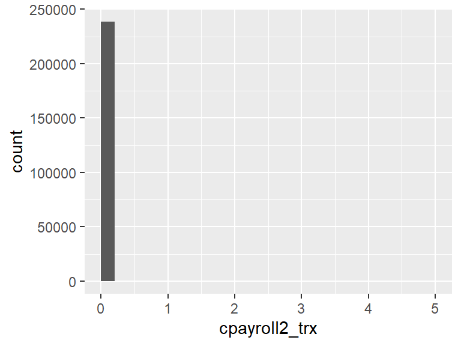

- Note that the following possible outlier values were detected: "1", "2", "3", "4", "5".

## ccuenta_debitos_automaticos

| Feature | Result |
| --- | --- |
| Variable type | integer |
| Number of missing obs. | 0 (0 %) |
| Number of unique values | 48 |
| Median | 0 |
| 1st and 3rd quartiles | 0; 2 |
| Min. and max. | 0; 72 |

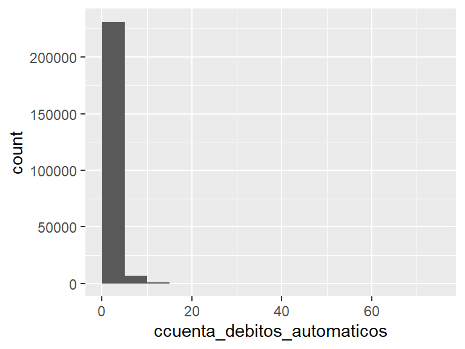

- Note that the following possible outlier values were detected: "64", "72".

## mcuenta_debitos_automaticos

| Feature | Result |
| --- | --- |
| Variable type | numeric |
| Number of missing obs. | 0 (0 %) |
| Number of unique values | 78653 |
| Median | 0 |
| 1st and 3rd quartiles | 0; 3082.01 |
| Min. and max. | 0; 28072624.64 |

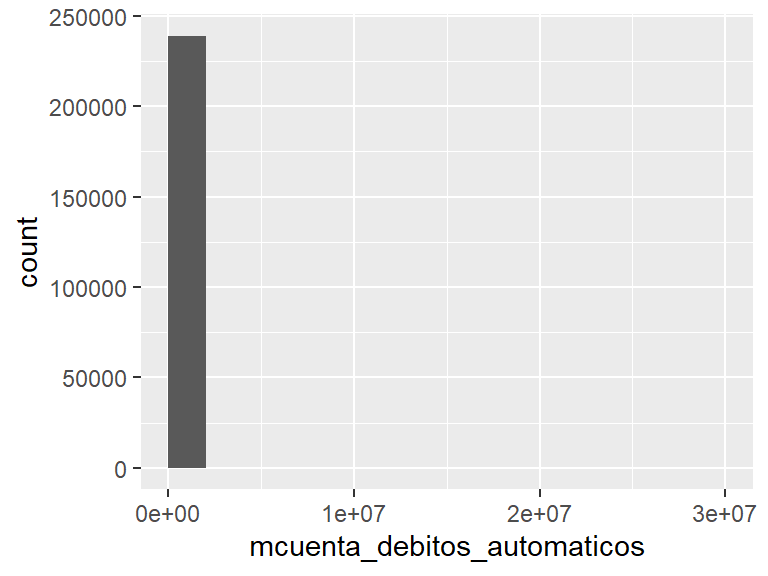

- Note that the following possible outlier values were detected: "96053.99", "96085.48", "96170.37", "96216.44", "96247.27", "96248.15", "96250.92", "96399.63", "96399.93", "96403.94" (2031 additional values omitted).

## ctarjeta_visa_debitos_automaticos

| Feature | Result |
| --- | --- |
| Variable type | integer |
| Number of missing obs. | 0 (0 %) |
| Number of unique values | 46 |
| Median | 1 |
| 1st and 3rd quartiles | 0; 3 |
| Min. and max. | 0; 64 |

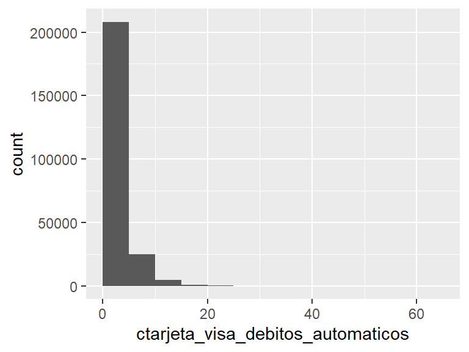

- Note that the following possible outlier values were detected: "24", "25", "26", "27", "28", "29", "30", "31", "32", "33" (12 additional values omitted).

## mttarjeta_visa_debitos_automaticos

| Feature | Result |
| --- | --- |
| Variable type | numeric |
| Number of missing obs. | 0 (0 %) |
| Number of unique values | 119767 |
| Median | 1459.41 |
| 1st and 3rd quartiles | 0; 7052.93 |
| Min. and max. | 0; 491246.13 |

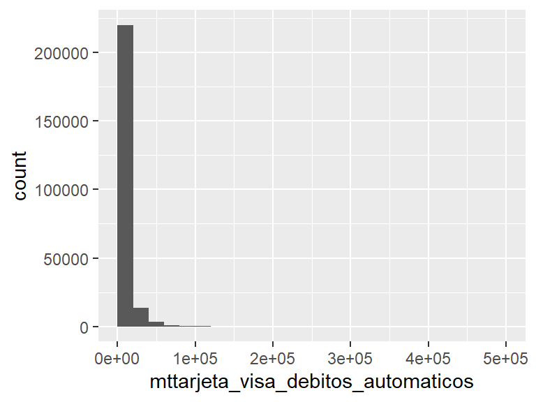

- Note that the following possible outlier values were detected: "79523.5", "79523.95", "79552.69", "79565.13", "79656.7", "79682.33", "79696.7", "79714.84", "79737.51", "79749.28" (824 additional values omitted).

## ctarjeta_master_debitos_automaticos

| Feature | Result |
| --- | --- |
| Variable type | integer |
| Number of missing obs. | 0 (0 %) |
| Number of unique values | 22 |
| Median | 0 |
| 1st and 3rd quartiles | 0; 0 |
| Min. and max. | 0; 53 |

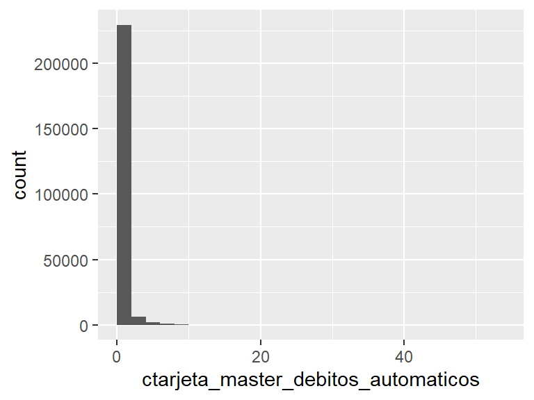

- Note that the following possible outlier values were detected: "1", "2", "3", "4", "5", "6", "7", "8", "9", "10" (11 additional values omitted).

## mttarjeta_master_debitos_automaticos

| Feature | Result |
| --- | --- |
| Variable type | numeric |
| Number of missing obs. | 0 (0 %) |
| Number of unique values | 25709 |
| Median | 0 |
| 1st and 3rd quartiles | 0; 0 |
| Min. and max. | 0; 454681.34 |

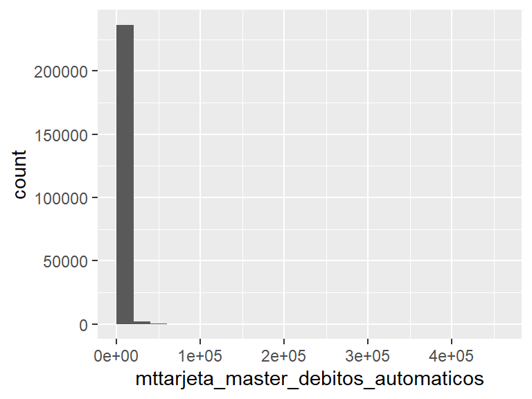

- Note that the following possible outlier values were detected: "1.17", "1.2", "1.55", "1.56", "2.18", "2.24", "2.25", "2.73", "3.06", "5.2" (25698 additional values omitted).

## cpagodeservicios

| Feature | Result |
| --- | --- |
| Variable type | integer |
| Number of missing obs. | 0 (0 %) |
| Number of unique values | 23 |
| Median | 0 |
| 1st and 3rd quartiles | 0; 0 |
| Min. and max. | 0; 25 |

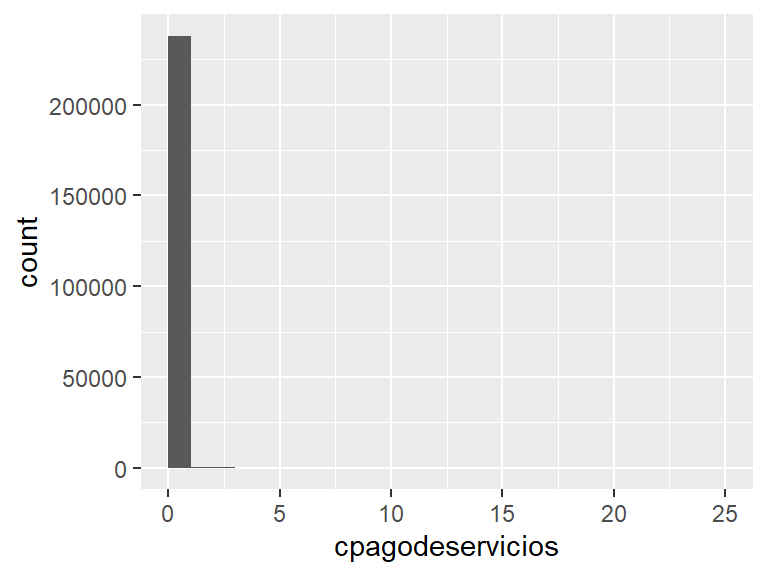

- Note that the following possible outlier values were detected: "1", "2", "3", "4", "5", "6", "7", "8", "9", "10" (12 additional values omitted).